# Tugas Praktikum 2 MPDW

Raihana Asma Amani_G1401221039

2024-09-02

# Pemanggilan *Packages*

```r
library(dplyr)
library(TTR)
library(forecast)
library(lmtest) #digunakan untuk uji formal pendeteksian autokorelasi
library(orcutt) #untuk membuat model regresi Cochrane-Orcutt
library(HoRM) #untuk membuat model regresi Hildreth-Lu
```

# Input Data

Data yang digunakan dalam kesempatan kali ini adalah data GDP negara Chad periode tahun 1994-2013.

```r
library("readxl")
gdp1 <- read_xlsx("C:/Users/raiha/Downloads/SEMESTER 5/MPDW/TUGAS INDIVIDU/PERTEMUAN 2/data 1994-2013.xlsx")
tahun <- gdp1$Tahun
gdp <- gdp1$GDP
gdp1
```

```
## # A tibble: 20 × 2
##    Tahun          GDP
##    <dbl>        <dbl>
##  1  1994  1179837963.
##  2  1995  1445919895.
##  3  1996  1607345356.
##  4  1997  1544689577.
##  5  1998  1744794531.
##  6  1999  1534673583.
##  7  2000  1388506772.
##  8  2001  1710843377.
##  9  2002  1997005709.
## 10  2003  2742815072.
## 11  2004  4422855661.
## 12  2005  6649307524.
## 13  2006  7428701454.
## 14  2007  8650137743.
## 15  2008 10393833765.
## 16  2009  9290728319.
## 17  2010 10668103554.
## 18  2011 12172308851.
## 19  2012 12367362757.
## 20  2013 12953534866.
```

# Eksplorasi Data

Sebelum melakukan regresi, akan diperlihatkan *plot time-series* dari GDP negara Chad periode tahun 1994-2013.

```r
#Membentuk objek time series
gdp1.ts<-ts(gdp1$GDP)
gdp1.ts
```

```
## Time Series:
## Start = 1
## End = 20
## Frequency = 1
##  [1]  1179837963  1445919895  1607345356  1544689577  1744794531  1534673583
##  [7]  1388506772  1710843377  1997005709  2742815072  4422855661  6649307524
## [13]  7428701454  8650137743 10393833765  9290728319 10668103554 12172308851
## [19] 12367362757 12953534866
```

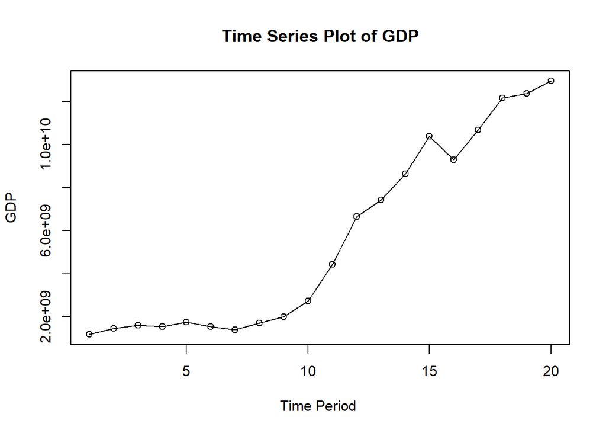

```r
#Membuat plot time series
ts.plot(gdp1.ts, xlab="Time Period ", ylab="GDP", main= "Time Series Plot of GDP")
points(gdp1.ts)
```

Selanjutnya akan dilakukan ramalan dan pemulusan dengan metode DMA dan DES karena terlihat pada plot di atas menunjukkan adanya *trend*.

```r
gdp1.sma <- SMA(gdp1.ts, n=3)
dma <- SMA(gdp1.sma, n = 3)
At <- 2*gdp1.sma - dma
Bt <- 2/(3-1)*(gdp1.sma - dma)
gdp1.dma<- At+Bt
gdp1.ramal<- c(NA, gdp1.dma)

t = 1:5
f = c()

for (i in t) {
  f[i] = At[length(At)] + Bt[length(Bt)]*(i)
}
```

```r
dt.gab <- cbind(aktual = c(gdp1.ts,rep(NA,5)),
                pemulusan1 = c(gdp1.sma,rep(NA,5)),
                pemulusan2 = c(gdp1.dma, rep(NA,5)),
                At = c(At, rep(NA,5)),
                Bt = c(Bt,rep(NA,5)),
                ramalan = c(gdp1.ramal, f[-1]))
dt.gab
```

```
##            aktual  pemulusan1  pemulusan2          At         Bt     ramalan
##  [1,]  1179837963          NA          NA          NA         NA          NA
##  [2,]  1445919895          NA          NA          NA         NA          NA
##  [3,]  1607345356  1411034405          NA          NA         NA          NA
##  [4,]  1544689577  1532651609          NA          NA         NA          NA
##  [5,]  1744794531  1632276488  1846187796  1739232142  106955654          NA
##  [6,]  1534673583  1608052564  1642170584  1625111574   17059010  1846187796
##  [7,]  1388506772  1555991629  1470427766  1513209697  -42781931  1642170584
##  [8,]  1710843377  1544674577  1494877885  1519776231  -24898346  1470427766
##  [9,]  1997005709  1698785286  1896721530  1797753408   98968122  1494877885
## [10,]  2742815072  2150221386  2854876658  2502549022  352327636  1896721530
## [11,]  4422855661  3054225480  4560521673  3807373577  753148096  2854876658
## [12,]  6649307524  4604992752  7275351844  5940172298 1335179546  4560521673
## [13,]  7428701454  6166954879  9283415897  7725185388 1558230509  7275351844
## [14,]  8650137743  7576048907 10496149029  9036098968 1460050061  9283415897
## [15,] 10393833765  8824224321 11427854224 10126039273 1301814952 10496149029
## [16,]  9290728319  9444899943 11104584381 10274742162  829842219 11427854224
## [17,] 10668103554 10117555213 11428212654 10772883934  655328721 11104584381
## [18,] 12172308851 10710380241 11949250460 11329815351  619435109 11428212654
## [19,] 12367362757 11735925054 13498534823 12617229939  881304885 11949250460
## [20,] 12953534866 12497735492 14197179283 13347457387  849721896 13498534823
## [21,]          NA          NA          NA          NA         NA 14197179283
## [22,]          NA          NA          NA          NA         NA 15046901179
## [23,]          NA          NA          NA          NA         NA 15896623075
## [24,]          NA          NA          NA          NA         NA 16746344971
## [25,]          NA          NA          NA          NA         NA 17596066867
```

```r
#tentukan rentang ylim berdasarkan data yang digabung
ylim_range <- range(c(dt.gab[,1],dt.gab[,3],dt.gab[,6]), na.rm = TRUE)
ylim_range
```

```
## [1]  1179837963 17596066867
```

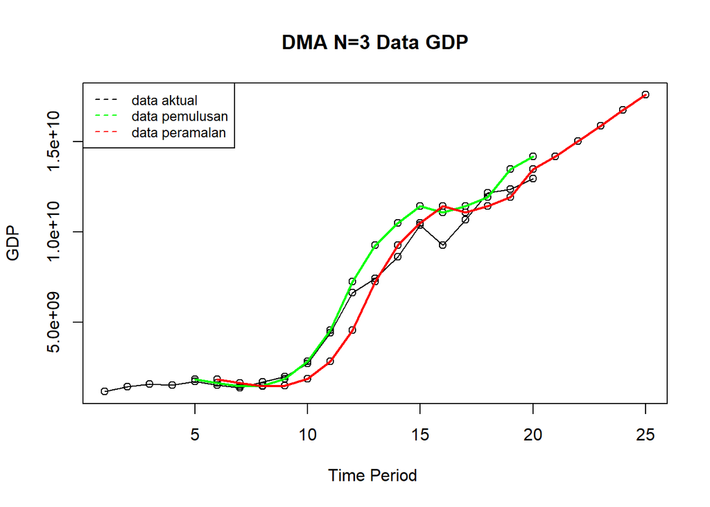

```r
#Plot time series
ts.plot(dt.gab[,1], xlab="Time Period ", ylab="GDP",
        main= "DMA N=3 Data GDP", ylim=ylim_range)
points(dt.gab[,1])
points(dt.gab[,3])
points(dt.gab[,6])
lines(dt.gab[,3],col="green",lwd=2)
lines(dt.gab[,6],col="red",lwd=2)
legend("topleft",c("data aktual","data pemulusan","data peramalan"),
       lty=8, col=c("black","green","red"), cex=0.8)
```

Selanjutnya akan dilihat keakuratan dari metode DMA

```r
#Menghitung nilai keakuratan
error.dma = gdp1.ts-gdp1.ramal[1:length(gdp1.ts)]
SSE.dma = sum(error.dma[6:length(gdp1.ts)]^2)
MSE.dma = mean(error.dma[6:length(gdp1.ts)]^2)
MAPE.dma = mean(abs((error.dma[6:length(gdp1.ts)]/gdp1.ts[6:length(gdp1.ts)])*100))

akurasi.dma <- matrix(c(SSE.dma, MSE.dma, MAPE.dma))
row.names(akurasi.dma)<- c("SSE", "MSE", "MAPE")
colnames(akurasi.dma) <- c("Akurasi m = 3")
akurasi.dma
```

```
##      Akurasi m = 3
## SSE   1.422715e+19
## MSE   9.484765e+17
## MAPE  1.510945e+01
```

Selanjutnya akan digunakan metode *Double Exponential Smoothing* dengan cara sebagai berikut.

Pertama akan data akan dibagi menjadi data *training* dan data *testing*.

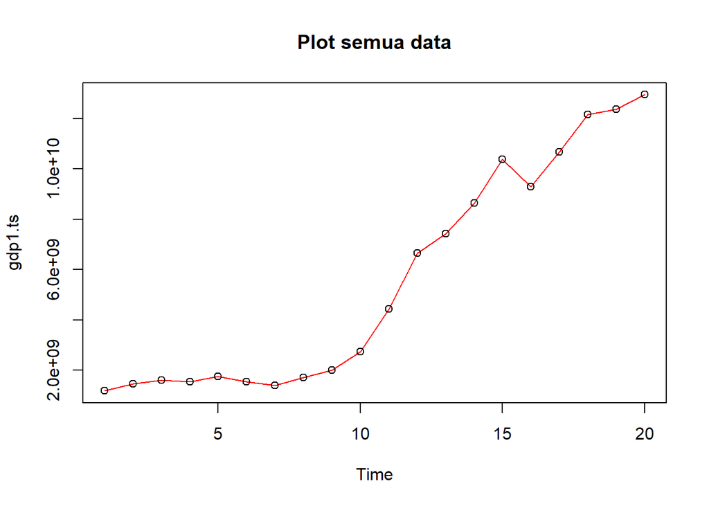

```r
#membagi training dan testing
training<-gdp1[1:16,2]
testing<-gdp1[17:20,2]

#data time series
training.ts<-ts(training, start=1994)
testing.ts<-ts(testing,start=2011)

#eksplorasi data
plot(gdp1.ts, col="red",main="Plot semua data")
points(gdp1.ts)
```

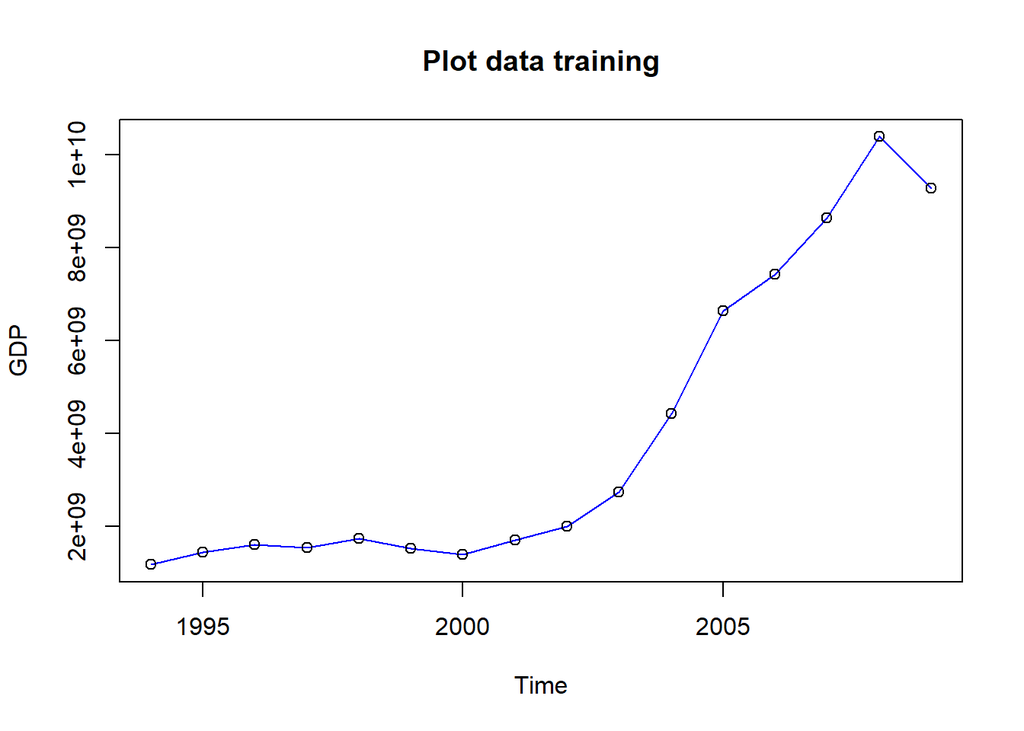

```r
plot(training.ts, col="blue",main="Plot data training")
points(training.ts)
```

Selanjutnya akan dilakukan pemulusan dengan DES, kali ini langsung dicari lambda dan gamma optimum sebagai berikut. Nilai lambda dan gamma optimum dapat dilihat pada smoothing parameters alpha untuk nilai lambda dan beta untuk nilai gamma.

```r
#Lamda dan gamma optimum
des.opt<- HoltWinters(training.ts, gamma = FALSE)
des.opt
```

```
## Holt-Winters exponential smoothing with trend and without seasonal component.
##
## Call:
## HoltWinters(x = training.ts, gamma = FALSE)
##
## Smoothing parameters:
##  alpha: 0.6851861
##  beta : 1
##  gamma: FALSE
##
## Coefficients:
##          [,1]
## a 10029885384
## b  -210049724
```

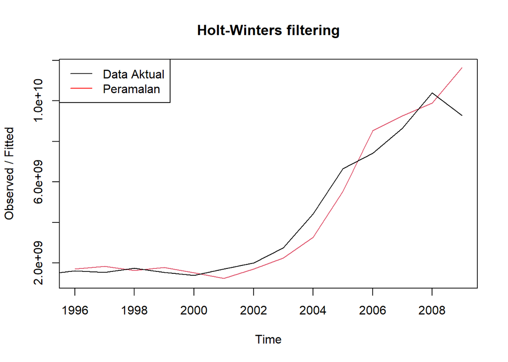

```r
plot(des.opt)
legend("topleft", c("Data Aktual", "Peramalan"), col = c("black", "red"),
       lty = c(1,1))
```

```r
#ramalan
ramalandesopt<- forecast(des.opt, h=5)
ramalandesopt
```

```
##      Point Forecast      Lo 80       Hi 80      Lo 95       Hi 95
## 2010     9819835660 8660635119 10979036201 8046991420 11592679900
## 2011     9609785936 7643267997 11576303876 6602256282 12617315590
## 2012     9399736212 6310246228 12489226196 4674769023 14124703401
## 2013     9189686488 4758125137 13621247839 2412198265 15967174711
## 2014     8979636764 3028983085 14930290443 -121102690 18080376218
```

Selanjutnya akan dicari akurasi dari metode DES.

```r
ssedes.train<-des.opt$SSE
msedes.train<-ssedes.train/length(training.ts)
sisaandes<-ramalandesopt$residuals
head(sisaandes)
```

```
## Time Series:
## Start = 1994
## End = 1999
## Frequency = 1
##               x
## [1,]         NA
## [2,]         NA
## [3,] -104656470
## [4,] -289975873
## [5,]  113131152
## [6,] -247706925
```

```r
mapedes.train <- sum(abs(sisaandes[3:length(training.ts)]/training.ts[3:length(training.ts)])*100)/length(training.ts)

akurasides.opt <- matrix(c(ssedes.train,msedes.train,mapedes.train))
row.names(akurasides.opt)<- c("SSE", "MSE", "MAPE")
colnames(akurasides.opt) <- c("Akurasi lamda dan gamma optimum")
akurasides.opt
```

```
##      Akurasi lamda dan gamma optimum
## SSE                     1.067074e+19
## MSE                     6.669210e+17
## MAPE                    1.326886e+01
```

```r
#Akurasi data testing
selisihdesopt<-ramalandesopt$mean-testing.ts
selisihdesopt
```

```
## Time Series:
## Start = 2011
## End = 2014
## Frequency = 1
##       testing.ts
## [1,] -1058317618
## [2,] -2772572639
## [3,] -3177676269
## [4,] -3973898103
```

```r
SSEtestingdesopt<-sum(selisihdesopt^2)
SSEtestingdesopt<-SSEtestingdesopt/length(testing.ts)
MAPEtestingdesopt<-sum(abs(selisihdesopt/testing.ts)*100)/length(testing.ts)

akurasiDesTesting <- matrix(c(SSEtestingdesopt,SSEtestingdesopt,MAPEtestingdesopt))
row.names(akurasiDesTesting)<- c("SSE", "MSE", "MAPE")
colnames(akurasiDesTesting) <- c("Akurasi lamda dan gamma optimum")
akurasiDesTesting
```

```
##      Akurasi lamda dan gamma optimum
## SSE                     8.674172e+18
## MSE                     8.674172e+18
## MAPE                    2.226756e+01
```

Setelah didapatkan nilai akurasi untuk metode DMA dan DES, selanjutnya akan dibandingkan keakuratan antar metode keduanya.

```r
cbind(akurasi.dma, akurasides.opt)
```

```
##      Akurasi m = 3 Akurasi lamda dan gamma optimum
## SSE   1.422715e+19                    1.067074e+19
## MSE   9.484765e+17                    6.669210e+17
## MAPE  1.510945e+01                    1.326886e+01
```

Berdasarkan perbandingan akurasi tersebut, terlihat nilai SSE, MSE, dan MAPE metode DES lebih kecil dibandingkan dengan metode DMA. Oleh karena itu, metode peramalan dan pemulusan yang terbaik antara keduanya adalah dengan metode DES.

Setelah melakukan peramalan, data yang telah dimasukkan kemudian dieksplorasi. Eksplorasi pertama yang dilakukan adalah dengan menggunakan *scatter plot*.

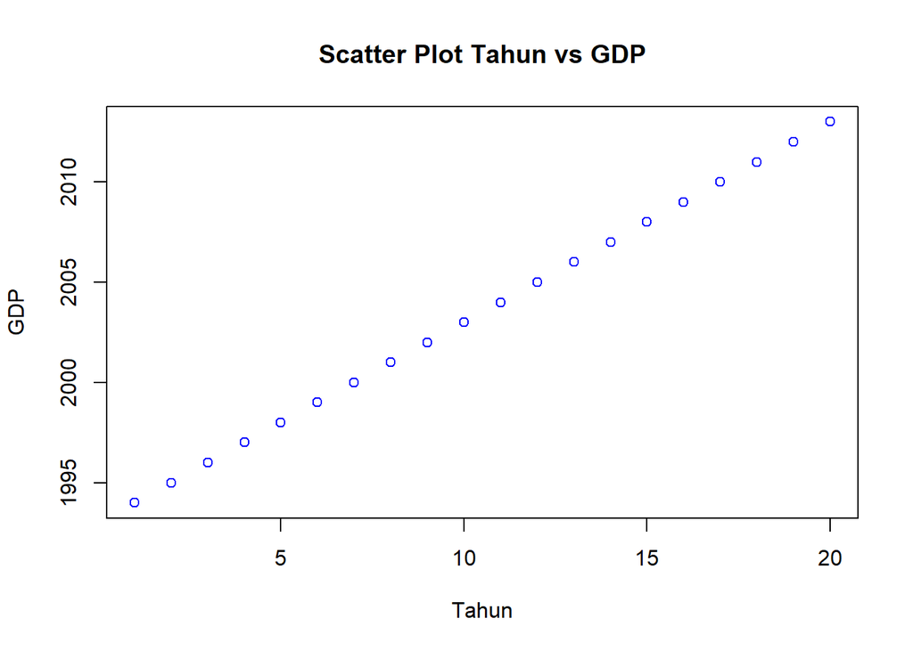

```r
#Eksplorasi Data
#Pembuatan Scatter Plot
plot(tahun, gdp = 20, col = "blue",
     main = "Scatter Plot Tahun vs GDP",
     xlab = "Tahun",
     ylab = "GDP")
```

```r
#Menampilkan Nilai Korelasi
cor(tahun,gdp)
```

```
## [1] 0.9453378
```

Setalah mengetahui adanya hubungan antar dua peubah, maka model regresi dapat ditentukan.

# Regresi

```r
#Pembuatan Model Regresi
#model regresi
model<- lm(gdp~tahun, data = gdp1)
summary(model)
```

```
##
## Call:
## lm(formula = gdp ~ tahun, data = gdp1)
##
## Residuals:
##        Min         1Q     Median         3Q        Max
## -2.533e+09 -1.031e+09  2.589e+08  8.668e+08  2.330e+09
##
## Coefficients:
##               Estimate Std. Error t value Pr(>|t|)
## (Intercept) -1.417e+12  1.156e+11  -12.25 3.61e-10 ***
## tahun        7.100e+08  5.772e+07   12.30 3.39e-10 ***
## ---
## Signif. codes:  0 '***' 0.001 '**' 0.01 '*' 0.05 '.' 0.1 ' ' 1
##
## Residual standard error: 1.489e+09 on 18 degrees of freedom
## Multiple R-squared:  0.8937, Adjusted R-squared:  0.8878
## F-statistic: 151.3 on 1 and 18 DF,  p-value: 3.391e-10
```

Model yang dihasilkan adalah
$$y_i=-1.417e^{12}+7.100e^{08}x_t$$
Berdasarkan ringkasan model dapat diketahui bahwa hasil uji F memiliki *p-value* < $\alpha$ (5%). Artinya, minimal terdapat satu variabel yang berpengaruh nyata terhadap model. Hasil uji-t parsial kedua parameter regresi, yaitu intersep dan koefisien regresi juga menunjukkan hal yang sama, yaitu memiliki *p-value* < $\alpha$ (5%) sehingga nyata dalam taraf 5%. Selanjutnya dapat dilihat juga nilai $R^2=0.8937$. Artinya, sebesar 89.37% keragaman nilai GDP dapat dijelaskan oleh peubah tahun. Hasil ini menunjukkan hasil yang bagus, seolah mendapatkan hasil terbaik. Namun, kita perlu melakukan uji terhadap sisaannya seperti berikut ini.

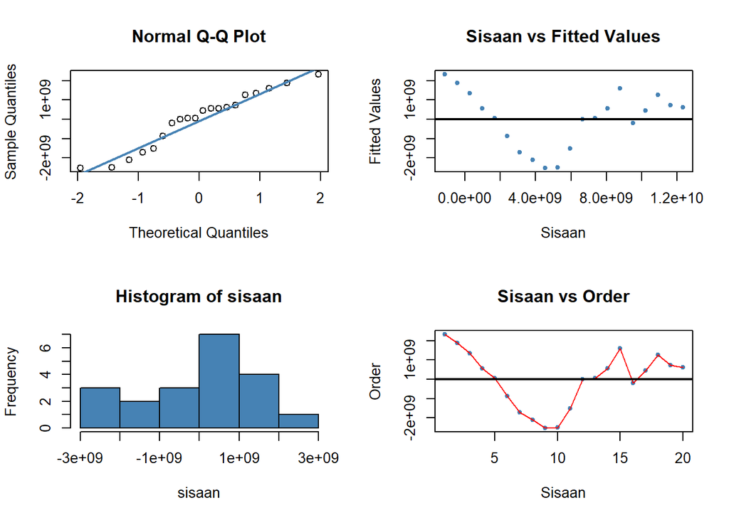

```r
#sisaan dan fitted value
sisaan<- residuals(model)
fitValue<- predict(model)

#Diagnostik dengan eksploratif
par(mfrow = c(2,2))
qqnorm(sisaan)
qqline(sisaan, col = "steelblue", lwd = 2)
plot(fitValue, sisaan, col = "steelblue", pch = 20, xlab = "Sisaan", ylab = "Fitted Values", main = "Sisaan vs Fitted Values")
abline(a = 0, b = 0, lwd = 2)
hist(sisaan, col = "steelblue")
plot(seq(1,20,1), sisaan, col = "steelblue", pch = 20, xlab = "Sisaan", ylab = "Order", main = "Sisaan vs Order")
lines(seq(1,20,1), sisaan, col = "red")
abline(a = 0, b = 0, lwd = 2)
```

Dua plot di samping kiri digunakan untuk melihat apakah sisaan menyebar normal. Normal Q-Q Plot di atas menunjukkan bahwa sisaan cenderung menyebar normal, tetapi histogram dari sisaan tidak menunjukkan demikian. Selanjutnya, dua plot di samping kanan digunakan untuk melihat autokorelasi. Plot Sisaan vs *Fitted Value* dan Plot Sisaan vs *Order* menunjukkan adanya pola pada sisaan. Untuk lebih lanjut akan digunakan uji formal melihat normalitas sisaan dan plot ACF dan PACF untuk melihat apakah ada autokorelasi atau tidak.

```r
#Melihat Sisaan Menyebar Normal/Tidak
#H0: sisaan mengikuti sebaran normal
#H1: sisaan tidak mengikuti sebaran normal
shapiro.test(sisaan)
```

```
##
##  Shapiro-Wilk normality test
##
## data:  sisaan
## W = 0.94322, p-value = 0.2756
```

```r
ks.test(sisaan, "pnorm", mean=mean(sisaan), sd=sd(sisaan))
```

```
##
##  Exact one-sample Kolmogorov-Smirnov test
##
## data:  sisaan
## D = 0.14717, p-value = 0.7257
## alternative hypothesis: two-sided
```

Berdasarkan uji formal Saphiro-Wilk dan Kolmogorov-Smirnov didapatkan nilai *p-value* > $\alpha$ (5%). Artinya, cukup bukti untuk menyatakan sisaan berdistribusi normal.

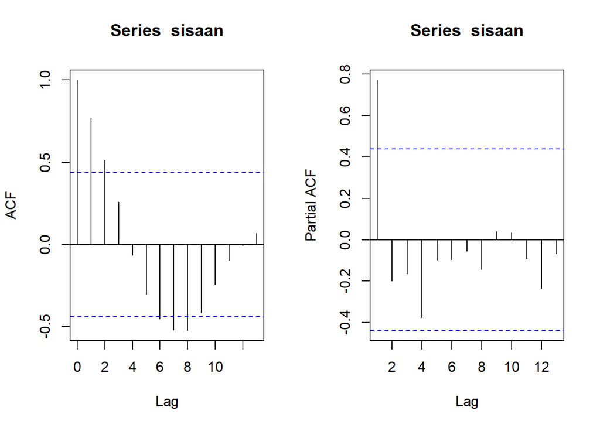

```r
#ACF dan PACF identifikasi autokorelasi
par(mfrow = c(1,2))
acf(sisaan)
pacf(sisaan)
```

Berdasarkan analisis ACF dan PACF, terlihat bahwa beberapa lag awal menunjukkan autokorelasi yang signifikan, ditandai dengan batang-batang yang melampaui batas signifikan (garis biru putus-putus). Hal ini mengindikasikan adanya potensi autokorelasi dalam residual pada beberapa lag. Untuk memastikan hal ini, langkah berikutnya adalah melakukan uji Durbin-Watson, yang memberikan penilaian lebih formal mengenai autokorelasi, terutama pada lag pertama. Jika hasil uji Durbin-Watson mengkonfirmasi adanya autokorelasi, maka model yang digunakan perlu diperbaiki untuk mengatasi masalah ini.

```r
#Deteksi autokorelasi dengan uji-Durbin Watson
#H0: tidak ada autokorelasi
#H1: ada autokorelasi
dwtest(model)
```

```
##
##  Durbin-Watson test
##
## data:  model
## DW = 0.31304, p-value = 1.268e-08
## alternative hypothesis: true autocorrelation is greater than 0
```

# Penanganan Autokorelasi

## Metode Cochrane-Orcutt

Penanganan metode Cochrane-Orcutt dapat dilakukan dengan bantuan packages Orcutt pada aplikasi `R` maupun secara manual. Berikut ini ditampilkan cara menggunakan bantuan `library` *packages* `Orcutt`.

```r
#Penanganan Autokorelasi Cochrane-Orcutt
modelCO<-cochrane.orcutt(model)
modelCO
```

```
## Cochrane-orcutt estimation for first order autocorrelation
##
## Call:
## lm(formula = gdp ~ tahun, data = gdp1)
##
##  number of interaction: 30
##  rho 0.784222
##
## Durbin-Watson statistic
## (original):    0.31304 , p-value: 1.268e-08
## (transformed): 1.86631 , p-value: 2.856e-01
##
##  coefficients:
##   (Intercept)         tahun
## -1.876171e+12  9.385423e+08
```

Hasil keluaran model setelah dilakukan penanganan adalah sebagai berikut.
$$y_i=-1.876171e^{12}+9.385423e^{08}
x_t$$
Hasil juga menunjukkan bahwa nilai DW dan p-value meningkat menjadi $1.86631$ dan $0.2856$. Nilai DW sudah berada pada rentang DU < DW < 4-DU atau $1.4107 < DW < 2.5893$. Hal tersebut juga didukung dengan nilai *p-value* > 0.05, artinya belum cukup bukti menyatakan bahwa sisaan terdapat autokorelasi pada taraf nyata 5%. Untuk nilai $ρ ̂$ optimum yang digunakan adalah $0.784222$. Nilai tersebut dapat diketahui dengan *syntax* berikut.

```r
#Rho optimum
rho<- modelCO$rho
rho
```

```
## [1] 0.7842218
```

Selanjutnya akan dilakukan transformasi secara manual dengan syntax berikut ini.

```r
gdp
```

```
##  [1]  1179837963  1445919895  1607345356  1544689577  1744794531  1534673583
##  [7]  1388506772  1710843377  1997005709  2742815072  4422855661  6649307524
## [13]  7428701454  8650137743 10393833765  9290728319 10668103554 12172308851
## [19] 12367362757 12953534866
```

```r
gdp[-1]
```

```
##  [1]  1445919895  1607345356  1544689577  1744794531  1534673583  1388506772
##  [7]  1710843377  1997005709  2742815072  4422855661  6649307524  7428701454
## [13]  8650137743 10393833765  9290728319 10668103554 12172308851 12367362757
## [19] 12953534866
```

```r
#Transformasi Manual
gdp.trans<- gdp[-1]-gdp[-20]*rho
tahun.trans<- tahun[-1]-tahun[-20]*rho
modelCOmanual<- lm(gdp.trans~tahun.trans)
summary(modelCOmanual)
```

```
##
## Call:
## lm(formula = gdp.trans ~ tahun.trans)
##
## Residuals:
##        Min         1Q     Median         3Q        Max
## -1.616e+09 -5.278e+08  5.215e+06  5.011e+08  1.235e+09
##
## Coefficients:
##               Estimate Std. Error t value Pr(>|t|)
## (Intercept) -4.048e+11  6.110e+10  -6.626 4.29e-06 ***
## tahun.trans  9.385e+08  1.410e+08   6.655 4.06e-06 ***
## ---
## Signif. codes:  0 '***' 0.001 '**' 0.01 '*' 0.05 '.' 0.1 ' ' 1
##
## Residual standard error: 726600000 on 17 degrees of freedom
## Multiple R-squared:  0.7226, Adjusted R-squared:  0.7063
## F-statistic: 44.28 on 1 and 17 DF,  p-value: 4.063e-06
```

```r
#Mencari Penduga Koefisien Regresi setelah Transformasi ke Persamaan Awal
b0bintang <- modelCOmanual$coefficients[-2]
b0 <- b0bintang/(1-rho)
b1 <- modelCOmanual$coefficients[-1]
b0
```

```
##   (Intercept)
## -1.876171e+12
```

```r
b1
```

```
## tahun.trans
##   938542305
```

Hasil perhitungan koefisien regresi tersebut akan menghasilkan hasil yang sama dengan model yang dihasilkan menggunakan *packages*.

## Metode Hildreth-Lu

Penanganan kedua adalah menggunakan metode Hildreth-Lu. Metode ini akan mencari nilai SSE terkecil dan dapat dicari secara manual maupun menggunakan packages. Jika menggunakan packages, gunakan `library` *packages* `HORM`.

```r
#Penanganan Autokorelasi Hildreth lu
# Hildreth-Lu
hildreth.lu.func<- function(r, model){
  x <- model.matrix(model)[,-1]
  y <- model.response(model.frame(model))
  n <- length(y)
  t <- 2:n
  y <- y[t]-r*y[t-1]
  x <- x[t]-r*x[t-1]

  return(lm(y~x))
}

#Pencariab rho yang meminimumkan SSE
r <- c(seq(0.1,0.9, by= 0.1))
tab <- data.frame("rho" = r, "SSE" = sapply(r, function(i){deviance(hildreth.lu.func(i, model))}))
round(tab, 4)
```

```
##   rho          SSE
## 1 0.1 2.742906e+19
## 2 0.2 2.242889e+19
## 3 0.3 1.821711e+19
## 4 0.4 1.479373e+19
## 5 0.5 1.215874e+19
## 6 0.6 1.031215e+19
## 7 0.7 9.253949e+18
## 8 0.8 8.984146e+18
## 9 0.9 9.502738e+18
```

Pertama-tama akan dicari di mana kira-kira $ρ$ yang menghasilkan SSE minimum. Pada hasil di atas terlihat $ρ$ minimum ketika 0.8. Namun, hasil tersebut masih kurang teliti sehingga akan dicari kembali $ρ$ yang lebih optimum dengan ketelitian yang lebih. Jika sebelumnya jarak antar $ρ$ yang dicari adalah 0.1, kali ini jarak antar $ρ$ adalah 0.001 dan dilakukan pada selang 0.7 sampai dengan 0.9.

```r
#Rho optimal di sekitar 0.8
rOpt <- seq(0.7,0.9, by= 0.001)
tabOpt <- data.frame("rho" = rOpt, "SSE" = sapply(rOpt, function(i){deviance(hildreth.lu.func(i, model))}))
head(tabOpt[order(tabOpt$SSE),])
```

```
##      rho          SSE
## 85 0.784 8.974334e+18
## 86 0.785 8.974356e+18
## 84 0.783 8.974391e+18
## 87 0.786 8.974457e+18
## 83 0.782 8.974527e+18
## 88 0.787 8.974636e+18
```

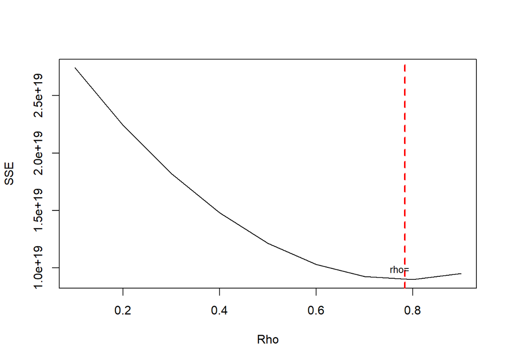

```r
#Grafik SSE optimum
par(mfrow = c(1,1))
plot(tab$SSE ~ tab$rho , type = "l", xlab = "Rho", ylab = "SSE")
abline(v = tabOpt[tabOpt$SSE==min(tabOpt$SSE),"rho"], lty = 2, col="red",lwd=2)
text(x=tabOpt [tabOpt$SSE ==min(tabOpt$SSE),"rho"],
     y=min(tab$SSE)+0.05*(max(tab$SSE)- min(tab$SSE)),
     labels=paste("rho="), round(tabOpt[tabOpt$SSE==min(tabOpt$SSE),"rho"],3),
     cex =0.8)
```

Perhitungan yang dilakukan aplikasi `R` menunjukkan bahwa nilai $ρ$ optimum, yaitu saat SSE terkecil terdapat pada nilai $ρ=0.784$. Hal tersebut juga ditunjukkan pada plot. Selanjutnya, model dapat didapatkan dengan mengevaluasi nilai $ρ$ ke dalam fungsi `hildreth.lu.func`, serta dilanjutkan dengan pengujian autokorelasi dengan uji Durbin-Watson. Namun, setelah pengecekan tersebut tidak lupa koefisien regresi tersebut digunakan untuk transformasi balik. Persamaan hasil transformasi itulah yang menjadi persamaan sesungguhnya.

```r
#Model terbaik
modelHL <- hildreth.lu.func(0.784, model)
summary(modelHL)
```

```
##
## Call:
## lm(formula = y ~ x)
##
## Residuals:
##        Min         1Q     Median         3Q        Max
## -1.616e+09 -5.279e+08  5.333e+06  5.008e+08  1.235e+09
##
## Coefficients:
##               Estimate Std. Error t value Pr(>|t|)
## (Intercept) -4.051e+11  6.110e+10  -6.631 4.25e-06 ***
## x            9.383e+08  1.409e+08   6.660 4.02e-06 ***
## ---
## Signif. codes:  0 '***' 0.001 '**' 0.01 '*' 0.05 '.' 0.1 ' ' 1
##
## Residual standard error: 726600000 on 17 degrees of freedom
## Multiple R-squared:  0.7229, Adjusted R-squared:  0.7066
## F-statistic: 44.35 on 1 and 17 DF,  p-value: 4.024e-06
```

```r
#Transformasi Balik
cat("y = ", coef(modelHL)[1]/(1-0.784), "+", coef(modelHL)[2],"x", sep = "")
```

```
## y = -1.875676e+12+938296561x
```

Setelah dilakukan tranformasi balik, didapatkan model dengan metode Hildreth-Lu sebagai berikut.
$$y_i=-1.875676e^{12}+938296561x_t$$

```r
#Deteksi autokorelasi
dwtest(modelHL)
```

```
##
##  Durbin-Watson test
##
## data:  modelHL
## DW = 1.8659, p-value = 0.2854
## alternative hypothesis: true autocorrelation is greater than 0
```

Terakhir, akan dibandingkan nilai SSE dari ketiga metode (metode awal, metode Cochrane-Orcutt, dan Hildreth-Lu).

```r
#Perbandingan
sseModelawal <- anova(model)$`Sum Sq`[-1]
sseModelCO <- anova(modelCOmanual)$`Sum Sq`[-1]
sseModelHL <- anova(modelHL)$`Sum Sq`[-1]
mseModelawal <- sseModelawal/length(gdp)
mseModelCO <- sseModelCO/length(gdp)
mseModelHL <- sseModelHL/length(gdp)
akurasi <- matrix(c(sseModelawal,sseModelCO,sseModelHL,
                    mseModelawal,mseModelCO,mseModelHL),nrow=2,ncol=3,byrow = T)
colnames(akurasi) <- c("Model Awal", "Model Cochrane-Orcutt", "Model Hildreth-Lu")
row.names(akurasi) <- c("SSE","MSE")
akurasi
```

```
##      Model Awal Model Cochrane-Orcutt Model Hildreth-Lu
## SSE 3.98832e+19          8.974332e+18      8.974334e+18
## MSE 1.99416e+18          4.487166e+17      4.487167e+17
```

# Simpulan

Autokorelasi yang terdapat pada data GDP terjadi akibat adanya korelasi di antara unsur penyusunnya. Indikator GDP yang erat hubungannya dengan perekonomian sangat rawan menjadi penyebab adanya autokorelasi. Adanya autokorelasi menyebabkan model regresi kurang baik karena akan meingkatkan galatnya. Autokorelasi dapat dideteksi secara eksploratif melalui plot sisaan, ACF, dan PACF, serta dengan uji formal Durbin-Watson. Namun, autokorelasi tersebut dapat ditangani dengan metode Cochrane-Orcutt dan Hildreth-Lu. Kedua metode menghasilkan nilai SSE yang sama, artinya keduanya baik untuk digunakan.